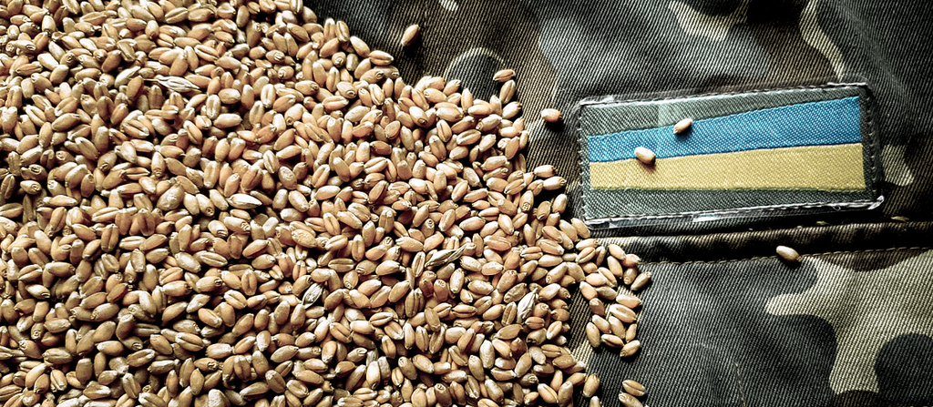

# EDA Black Sea Initiative Vessel Movements: Vessel Inspections' Delay

It's been a year since Russia's full-scale invation of Ukraine.

The Russian invasion of Ukraine in February led to a complete halt of maritime grain shipments from Ukraine, previously a major exporter via the Black Sea. This resulted in a rise in world food prices and the threat of famine in lower-income countries. To address the issue, discussions began in April, hosted by Turkey (which controls the maritime routes from the Black Sea) and supported by the UN. The resulting agreement was signed in Istanbul on 22 July 2022, valid for a period of 120 days.

The July agreement created procedures to safely export grain from certain ports to attempt to address the 2022 food crisis. Joint Coordination and Inspection Center was set up in Turkey, with the UN serving as secretariat.  
Russia suspended its participation in the agreement for several days due to a drone attack on Russian naval ships elsewhere in the Black Sea, but rejoined following mediation (for further infornation *see at* [Wikipedia](https://en.wikipedia.org/wiki/Black_Sea_Grain_Initiative)).  
The Black Sea Grain Initiative was designed to free up Ukrainian wheat, barley and other food critical to nations in Africa, the Middle East and Asia, where shortages of affordable supplies sent food prices surging and helped throw more people into poverty. (see [VOA](https://www.voanews.com/a/inspections-of-ukrainian-grain-ships-halved-since-october-/6928688.html))  
Russia is deliberately slowing down the grain agreement by extending the length of inspections for ships heading to and from its Black Sea ports.[Politico](https://www.politico.eu/article/ukraine-russia-garin-export-black-sea-delay/)

*This dataset contains the list of voyages undertaken by ships under Black Sea Graine Initiative since the 3rd of August, 2022. The dataset is downloaded from the Humanitarian Data Exchange [website](https://data.humdata.org/dataset/black-sea-grain-initiative-vessel-movements), open data platform managed by the United Nations Office for the Coordination of Humanitarian Affairs (OCHA) through its Centre for Humanitarian Data.*

Contributor of the data [Joint Coordination Centre](https://data.humdata.org/organization/63ffce1d-5237-485d-8f06-337d468b835c)

License [Creative Commons Attribution International](https://data.humdata.org/faqs/licenses)</i>

**The data are reviewed as of 7 March 2023.**

**The goal of the study is to analyse the number of inspections of vessels and the waiting time of vessels (downtime).**

> Intro: Import and Reading Data  
> Step 1: Data Understanding  
> Step 2: Data Preparation  
> Step 3: Feature Understanding  
> Step 4: Feature Relationship  
> Step 5: Question. To what extent could the total volume of commodities deliveries grow, given the current level of inspections, if vessel tonnage increases?  
> Coda: Brief Summary

### Intro: Import and Reading Data

```python
import numpy as np
import pandas as pd
import matplotlib.pyplot as plt
import seaborn as sns
from datetime import datetime
from collections import Counter
```

```python
# load dataset of outbound vessels

df_outbound = pd.read_csv("BSGI Outbound Shipments.csv")
```

### Step 1: Data Understanding

- head
- info
- describe
- dtypes

```python
df_outbound.head(2)
```

|  | Status | # | Vessel name | IMO | Departure port | Country | Commodity | Metric tons | Departure date | Inspection cleared | Income group | Flag | World Bank region | UN region | Development category |
| --- | --- | --- | --- | --- | --- | --- | --- | --- | --- | --- | --- | --- | --- | --- | --- |
| 0 | Outbound | 794 | SANTORINI ISLAND | 9393618 | Chornomorsk | Spain | Wheat | 44,000 | 7-Mar-2023 | NaN | high-income | Panama | Europe & Central Asia | Western Europe and Others | developed |
| 1 | Outbound | 793 | KARTERIA | 9236092 | Yuzhny/Pivdennyi | Türkiye | Soya beans | 44,000 | 7-Mar-2023 | NaN | upper-middle-income | Malta | Europe & Central Asia | Asia-Pacific | developing |

```python
df_outbound.info()
```

```
<class 'pandas.core.frame.DataFrame'>
RangeIndex: 897 entries, 0 to 896
Data columns (total 15 columns):
 #   Column                Non-Null Count  Dtype
---  ------                --------------  -----
 0   Status                897 non-null    object
 1   #                     897 non-null    int64
 2   Vessel name           897 non-null    object
 3   IMO                   897 non-null    int64
 4   Departure port        897 non-null    object
 5   Country               897 non-null    object
 6   Commodity             897 non-null    object
 7   Metric tons           897 non-null    object
 8   Departure date        897 non-null    object
 9   Inspection cleared    866 non-null    object
 10  Income group          897 non-null    object
 11  Flag                  895 non-null    object
 12  World Bank region     897 non-null    object
 13  UN region             897 non-null    object
 14  Development category  897 non-null    object
dtypes: int64(2), object(13)
memory usage: 105.2+ KB
```

```python
df_outbound.dtypes
```

```
Status                  object
#                        int64
Vessel name             object
IMO                      int64
Departure port          object
Country                 object
Commodity               object
Metric tons             object
Departure date          object
Inspection cleared      object
Income group            object
Flag                    object
World Bank region       object
UN region               object
Development category    object
dtype: object
```

```python
df_outbound.isna().sum()
```

```
Status                   0
#                        0
Vessel name              0
IMO                      0
Departure port           0
Country                  0
Commodity                0
Metric tons              0
Departure date           0
Inspection cleared      31
Income group             0
Flag                     2
World Bank region        0
UN region                0
Development category     0
dtype: int64
```

### Step 2: Data Preparation

- Renaming columns in pythonic way
- Managing missed values
- Feature creation
- Dropping irrelevant columns/rows
- Identifying duplicate rows/values  
  We immediately point out the missing values in the "Flag" and "Inspection cleared" columns. In addition, there is an even significant problem exists, that is the existence of the "Outbound +" row records of the categorical variable Status along with the value "Outbound" with the same unique vessel's IMO number at the same day.  
  But this is a cargo that was just additionally loaded onto the ship and thus marked with an additional row (record), as a result affecting the statistics of the number of ships inspected per day. This leads to an overestimate, since the ship will be counted two or three times a day (depending on the number of additional loads).

```python
df_outbound.columns
```

```
Index(['Status', '#', 'Vessel name', 'IMO', 'Departure port', 'Country',
       'Commodity', 'Metric tons', 'Departure date', 'Inspection cleared',
       'Income group', 'Flag', 'World Bank region', 'UN region',
       'Development category'],
      dtype='object')
```

```python
# rename column - make the columns' names pythonic

df_outbound.rename(mapper={
    'Status': 'status',
        '#': 'outbound_seq',
          'IMO': 'imo_number',
          'Vessel name': 'vessel_name',
          'Departure port': 'departure_port',
          'Country': 'destination_country',
          'Commodity': 'commodity',
          'Metric tons': 'tonnage',
          'Departure date': 'departure_date',
          'Inspection cleared': 'inspection_cleared',
          'Income group': 'income_group',
          'Flag': 'flag',
          'World Bank region': 'worldbank_region',
          'UN region': 'un_region',
          'Development category': 'dev_category'
        },
                        inplace=True, axis=1)
```

```python
df_outbound.head(2)
```

|  | status | outbound_seq | vessel_name | imo_number | departure_port | destination_country | commodity | tonnage | departure_date | inspection_cleared | income_group | flag | worldbank_region | un_region | dev_category |
| --- | --- | --- | --- | --- | --- | --- | --- | --- | --- | --- | --- | --- | --- | --- | --- |
| 0 | Outbound | 794 | SANTORINI ISLAND | 9393618 | Chornomorsk | Spain | Wheat | 44,000 | 7-Mar-2023 | NaN | high-income | Panama | Europe & Central Asia | Western Europe and Others | developed |
| 1 | Outbound | 793 | KARTERIA | 9236092 | Yuzhny/Pivdennyi | Türkiye | Soya beans | 44,000 | 7-Mar-2023 | NaN | upper-middle-income | Malta | Europe & Central Asia | Asia-Pacific | developing |

```python
# changing type of tonnage column from object/string to float

df_outbound.tonnage = df_outbound['tonnage'].str.replace(",", "").astype(float)

# changing dtype

df_outbound.departure_date = pd.to_datetime(df_outbound.departure_date)
df_outbound.inspection_cleared = pd.to_datetime(df_outbound.inspection_cleared)

df_outbound = df_outbound.astype({
    'outbound_seq': 'category',
    'imo_number': 'category',
    'income_group': 'category',
    'un_region': 'category',
    'income_group': 'category',
    'worldbank_region': 'category'})
```

Rows marked **"Outbound +"** are additional shipments on the same voyage - eg two or more commodities going to the same destination, or the same commodity to two destinations. Thus we have one vessel counted twice per given day in dataset.

For the purposes of this analysis, we must remove all rows with status "Outbound +" by adding the concealed tonnage from these rows to the total tonnage of the vessel (**with status just 'Outbound'**).

```python
df_outbound[df_outbound.status == 'Outbound +'].count()
```

```
status                 103
outbound_seq           103
vessel_name            103
imo_number             103
departure_port         103
destination_country    103
commodity              103
tonnage                103
departure_date         103
inspection_cleared      99
income_group           103
flag                   103
worldbank_region       103
un_region              103
dev_category           103
dtype: int64
```

```python
outbound_ajusted = df_outbound.copy(deep=True)
```

```python
vessel_imo_plus = list(outbound_ajusted[outbound_ajusted.status == 'Outbound +'].imo_number)
print("There ate {}  rows with additional shipment, i.e. shipment loaded at the same vessel ".format(len(vessel_imo_plus)))
```

```
There ate 103  rows with additional shipment, i.e. shipment loaded at the same vessel
```

```python
outbound_ajusted[outbound_ajusted.status == 'Outbound +'].head()
```

|  | status | outbound_seq | vessel_name | imo_number | departure_port | destination_country | commodity | tonnage | departure_date | inspection_cleared | income_group | flag | worldbank_region | un_region | dev_category |
| --- | --- | --- | --- | --- | --- | --- | --- | --- | --- | --- | --- | --- | --- | --- | --- |
| 12 | Outbound + | 783 | MAHA ROOS | 9231004 | Yuzhny/Pivdennyi | China | Sunflower meal | 17485.0 | 2023-03-04 | NaT | upper-middle-income | India | East Asia & Pacific | Asia-Pacific | developing |
| 20 | Outbound + | 776 | GENEVE | 9442926 | Yuzhny/Pivdennyi | Türkiye | Barley | 33000.0 | 2023-03-01 | NaT | upper-middle-income | Marshall Islands | Europe & Central Asia | Asia-Pacific | developing |
| 23 | Outbound + | 774 | ANDONIS | 9763916 | Yuzhny/Pivdennyi | China | Sunflower meal | 18700.0 | 2023-03-01 | NaT | upper-middle-income | Marshall Islands | East Asia & Pacific | Asia-Pacific | developing |
| 25 | Outbound + | 773 | NEW LIBERTY | 9221645 | Odesa | Egypt | Corn | 11000.0 | 2023-02-28 | NaT | lower-middle income | Belize | Middle East & North Africa | Africa | developing |
| 32 | Outbound + | 767 | LADY AYANA | 9196395 | Odesa | Egypt | Soya beans | 11939.0 | 2023-02-25 | 2023-03-07 | lower-middle income | Barbados | Middle East & North Africa | Africa | developing |

```python
outbound_ajusted[outbound_ajusted.status == 'Outbound +'].nunique()
```

```
status                  1
outbound_seq           92
vessel_name            87
imo_number             87
departure_port          3
destination_country    21
commodity              10
tonnage                92
departure_date         66
inspection_cleared     68
income_group            4
flag                   21
worldbank_region        5
un_region               3
dev_category            2
dtype: int64
```

There are 103 record with status 'Outbound +' but only 87 unique IMO number. This mean 1) some vessels performed more than one voyage or 2) we have to deal with human mistakes. Let's inspect that

```python
from collections import Counter

double_status = outbound_ajusted[outbound_ajusted.status == 'Outbound +'].imo_number
```

```python
# checking vessels with additional tonnage on board by IMO number and quantity of additional shipment

additional_shipments = Counter(list(double_status)).most_common(20)
```

```python
additional_shipments
```

```
[(9400928, 3),
 (9217826, 2),
 (9629823, 2),
 (9601883, 2),
 (9221592, 2),
 (9571428, 2),
 (9198381, 2),
 (9545510, 2),
 (9703241, 2),
 (9310604, 2),
 (9604782, 2),
 (9146962, 2),
 (9171541, 2),
 (9663104, 2),
 (9174268, 2),
 (9231004, 1),
 (9442926, 1),
 (9763916, 1),
 (9221645, 1),
 (9196395, 1)]
```

```python
# droppin entire row in category status 'Outbound +' - subsetting additional shipment

outbound_dropped = outbound_ajusted.drop(outbound_ajusted[outbound_ajusted.status == 'Outbound +'].index, inplace=False)
```

```python
# fill missed value in flag column

missed_flag = df_outbound.flag.isna()
df_outbound[missed_flag]
```

|  | status | outbound_seq | vessel_name | imo_number | departure_port | destination_country | commodity | tonnage | departure_date | inspection_cleared | income_group | flag | worldbank_region | un_region | dev_category |
| --- | --- | --- | --- | --- | --- | --- | --- | --- | --- | --- | --- | --- | --- | --- | --- |
| 48 | Outbound | 754 | ROYAL STAR | 9223813 | Odesa | Afghanistan | Wheat | 25000.0 | 2023-02-19 | 2023-02-27 | low-income | NaN | South Asia | Asia-Pacific | developing |
| 691 | Outbound | 180 | CENK M | 7382366 | Chornomorsk | Türkiye | Sunflower seed | 90.0 | 2022-09-21 | 2022-10-08 | upper-middle-income | NaN | Europe & Central Asia | Asia-Pacific | developing |

```python
# fill  missed flag of the vessels with values found by unique IMO number at https://www.vesselfinder.com/

df_outbound.loc[df_outbound.imo_number == 9223813, ['flag']] = "Panama"
df_outbound.loc[df_outbound.imo_number == 7382366, ['flag']] = "Comoros"
```

**Subsetting records without missed inspection date** We can see that some data is missed in inspection_date column for a very logical reason. There are the vessels that are still waiting inspection at the date of analysis. This is structurally missing data (SMD). For further consideration, we will not take these rows into account.

```python
# subsetting vessels with cleared inspection

not_cleared = df_outbound.inspection_cleared.isna()
df_cleared = df_outbound[~not_cleared].copy()
```

```python
num_vessels, cols = df_outbound[not_cleared].shape
print('There are {} vessels waiting inspection clearence as of March, 4 2023'.format(num_vessels))
```

```
There are 31 vessels waiting inspection clearence as of March, 4 2023
```

```python
# subsetting 'Outbound +' rows for further calculation of additional tonnage after dropping those raws

df_outbound_plus = df_cleared[df_cleared.status == 'Outbound +'].copy()
df_outbound_plus.info()
```

```
<class 'pandas.core.frame.DataFrame'>
Int64Index: 99 entries, 32 to 896
Data columns (total 15 columns):
 #   Column               Non-Null Count  Dtype
---  ------               --------------  -----
 0   status               99 non-null     object
 1   outbound_seq         99 non-null     category
 2   vessel_name          99 non-null     object
 3   imo_number           99 non-null     category
 4   departure_port       99 non-null     object
 5   destination_country  99 non-null     object
 6   commodity            99 non-null     object
 7   tonnage              99 non-null     float64
 8   departure_date       99 non-null     datetime64[ns]
 9   inspection_cleared   99 non-null     datetime64[ns]
 10  income_group         99 non-null     category
 11  flag                 99 non-null     object
 12  worldbank_region     99 non-null     category
 13  un_region            99 non-null     category
 14  dev_category         99 non-null     object
dtypes: category(5), datetime64[ns](2), float64(1), object(7)
memory usage: 69.1+ KB
```

```python
# subsetting 'Outbound +' rows for further calculation of additional tonnage after dropping those raws

df_outbound_plus = df_cleared[df_cleared.status == 'Outbound +'].copy()
df_outbound_plus.info()
```

```
<class 'pandas.core.frame.DataFrame'>
Int64Index: 99 entries, 32 to 896
Data columns (total 15 columns):
 #   Column               Non-Null Count  Dtype
---  ------               --------------  -----
 0   status               99 non-null     object
 1   outbound_seq         99 non-null     category
 2   vessel_name          99 non-null     object
 3   imo_number           99 non-null     category
 4   departure_port       99 non-null     object
 5   destination_country  99 non-null     object
 6   commodity            99 non-null     object
 7   tonnage              99 non-null     float64
 8   departure_date       99 non-null     datetime64[ns]
 9   inspection_cleared   99 non-null     datetime64[ns]
 10  income_group         99 non-null     category
 11  flag                 99 non-null     object
 12  worldbank_region     99 non-null     category
 13  un_region            99 non-null     category
 14  dev_category         99 non-null     object
dtypes: category(5), datetime64[ns](2), float64(1), object(7)
memory usage: 69.1+ KB
```

```python
# Obtaining unique set for every additional shipment onboard (date, imo number, tonnage)

add_shipment = []

for index, row in df_outbound_plus.iterrows():
    date_plus = row.inspection_cleared
    imo_plus = row.imo_number
    tonnage_plus = row.tonnage
    add_shipment.append((date_plus, imo_plus, tonnage_plus))

print(add_shipment[:5])
```

```
[(Timestamp('2023-03-07 00:00:00'), 9196395, 11939.0), (Timestamp('2023-03-07 00:00:00'), 9217826, 11755.0), (Timestamp('2023-03-06 00:00:00'), 9584592, 20000.0), (Timestamp('2023-02-28 00:00:00'), 9629823, 25000.0), (Timestamp('2023-03-03 00:00:00'), 9316995, 4000.0)]
```

```python
# Check point: actual total tonnage to check after manipulation

df_cleared.tonnage.sum()
```

```
22232894.0
```

```python
df_cleared.head()
```

|  | status | outbound_seq | vessel_name | imo_number | departure_port | destination_country | commodity | tonnage | departure_date | inspection_cleared | income_group | flag | worldbank_region | un_region | dev_category |
| --- | --- | --- | --- | --- | --- | --- | --- | --- | --- | --- | --- | --- | --- | --- | --- |
| 31 | Outbound | 767 | LADY AYANA | 9196395 | Odesa | Egypt | Corn | 14068.0 | 2023-02-25 | 2023-03-07 | lower-middle income | Barbados | Middle East & North Africa | Africa | developing |
| 32 | Outbound + | 767 | LADY AYANA | 9196395 | Odesa | Egypt | Soya beans | 11939.0 | 2023-02-25 | 2023-03-07 | lower-middle income | Barbados | Middle East & North Africa | Africa | developing |
| 33 | Outbound | 766 | EAGLE TRADER | 9284362 | Odesa | France | Sunflower meal | 20200.0 | 2023-02-25 | 2023-03-07 | high-income | Barbados | Europe & Central Asia | Western Europe and Others | developed |
| 34 | Outbound | 765 | AK HALIMA | 9217826 | Chornomorsk | Italy | Wheat | 11209.0 | 2023-02-25 | 2023-03-07 | high-income | Barbados | Europe & Central Asia | Western Europe and Others | developed |
| 35 | Outbound + | 765 | AK HALIMA | 9217826 | Chornomorsk | Italy | Corn | 11755.0 | 2023-02-25 | 2023-03-07 | high-income | Barbados | Europe & Central Asia | Western Europe and Others | developed |

```python
# adjusting the overall tonnage of the vessel with 'Outbound +' shipment

for item in range(len(add_shipment)):

    date_plus = add_shipment[item][0]
    imo_plus = add_shipment[item][1]
    tonnage_plus = add_shipment[item][2]

    condition = (df_cleared.status == 'Outbound') \
                    & (df_cleared.inspection_cleared == date_plus) \
                    & (df_cleared.imo_number == imo_plus)
    df_cleared.loc[condition, ['tonnage']] = df_cleared.tonnage + tonnage_plus
```

```python
# extra tonnage appear in total

df_cleared.tonnage.sum()
```

```
23654388.0
```

```python
# dropping "Outbound +" rows

final_df = df_cleared.drop(df_cleared[df_cleared.status == 'Outbound +'].index).reset_index(drop=True).copy()
```

```python
# Check point: tonnage after droping "Outbound +" with corrected overall tonnage of the voyage

final_df.tonnage.sum()
```

```
22232894.0
```

```python
final_df['downtime'] = (final_df.inspection_cleared - final_df.departure_date).dt.days
```

### Step 3: Feature Understanding

(Univariate analysis)

- Ploting Feature Distribution
  > - hystogram
  > - boxplot
- Ploting time series

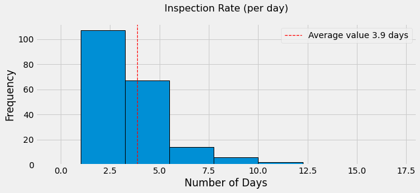

```python
# inspection rate distribution

plt.style.use('fivethirtyeight')
df_inum = final_df.inspection_cleared.value_counts().sort_index().reset_index()
df_inum.columns = ['date','number_of_inspection']

inum_avg = df_inum.number_of_inspection.mean()

ax = df_inum.number_of_inspection.hist(figsize=(10,4),
                                       bins=20,
                                       edgecolor='black',
                                       linewidth=1.)
ax.set_title('Inspection Rate (per day)',
             fontsize=16,
             pad=20)
ax.set_xlabel('Number of Days')
ax.set_ylabel('Frequency')
ax.set_xlim(right=18)
plt.axvline(inum_avg,
           color='red',
           linestyle='--',
           linewidth=1.2,
           label='Average value ' + str(round(inum_avg, 1)) + ' days')

plt.legend(fontsize=14)

plt.show()
```

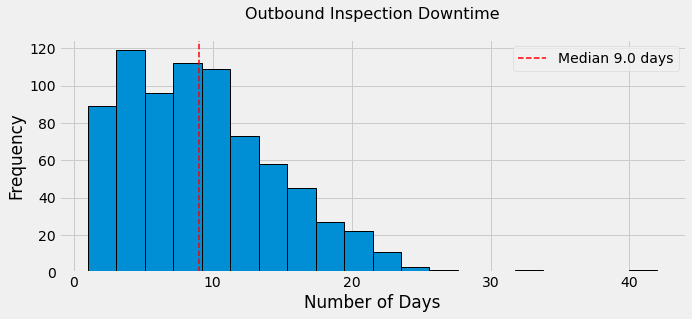

```python
# downtime distribution

downtime_median = final_df.downtime.median()
plt.style.use('fivethirtyeight')

ax = final_df.downtime.hist(figsize=(10,4),
                                     bins=20,
                                     edgecolor='black',
                                     linewidth=1.)

ax.set_xlabel('Number of Days')
ax.set_ylabel('Frequency')
plt.axvline(downtime_median,
           linestyle='--',
           color='red',
           linewidth=1.5,
           label = 'Median ' + str(round(downtime_median,1)) + ' days')
ax.set_title('Outbound Inspection Downtime',
             fontsize=16,
             pad=20)
plt.legend(fontsize=14)
plt.show()
```

```python
final_df[final_df.downtime < 20]['downtime'].mean()
```

```
8.872252747252746
```

```python
inspected_mean = final_df['downtime'].mean()
```

```python
final_df.downtime.quantile(0.95)
```

```
19.699999999999932
```

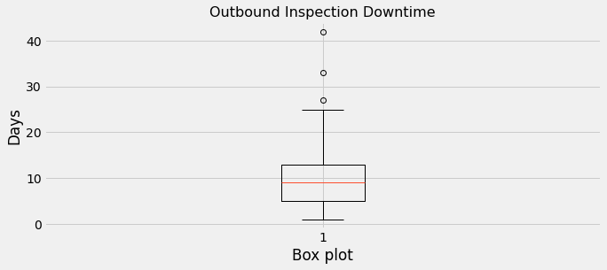

```python
fig, ax = plt.subplots(figsize=(10,4))
ax = plt.boxplot(final_df.downtime)
plt.xlabel('Box plot')
plt.ylabel('Days')
plt.title('Outbound Inspection Downtime',
         fontsize=16)

plt.show()
```

[figure not shown]

```python
sns.set()
fig, ax = plt.subplots(figsize=(12,6))
sns.set_style("darkgrid")
sns.violinplot(ax=ax,
               data=final_df,
               x='un_region',
               y='downtime',
              linewidth = 1)
plt.title('Downtime by UN region destinations',
          color='darkblue',
          fontsize=18,
         pad=20)
plt.xticks(fontsize=14)
plt.yticks(fontsize=14)
ax.axhline(inspected_mean,
           linestyle='--',
           color='red',
           linewidth=1.5,
          label = 'Median')
plt.xlabel('United Nations Region', fontsize=16, color='black')
plt.ylabel('Downtime, days', fontsize=16)
plt.legend()
plt.show()
```

[figure not shown]

```python
fig, ax = plt.subplots(figsize=(12,6))
sns.set_style("darkgrid")
sns.violinplot(ax=ax,
               data=final_df,
               x='worldbank_region',
               y='downtime',
              linewidth = 1)
plt.title('Downtime by World Bank region destinations',
          color='darkblue',
          fontsize=18,
         pad=20)
plt.xticks(fontsize=14)
plt.yticks(fontsize=14)
ax.axhline(inspected_mean,
           linestyle='--',
           color='red',
           linewidth=1.5,
          label = 'Median')
plt.xlabel('World Bank Region', fontsize=16, color='black')
plt.ylabel('Downtime, days', fontsize=16)
plt.legend()
plt.show()
```

**Thus, we do not see any signs of preference in delaying ship inspections depending on the region where the cargo is going.**

### Step 4: Feature Relationship

```python
# Build a heatmap - average number of inspection per weekday for every months

df_reldate = final_df.inspection_cleared.value_counts().sort_index().reset_index()
df_reldate.columns = ['Date','Number of Inspection']
df_reldate['Month'] = df_reldate['Date'].dt.month
df_reldate['Weekday'] = df_reldate['Date'].dt.weekday
```

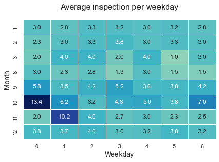

```python
# Mean of inspections per day of week for each month

sns.heatmap(pd.crosstab(df_reldate['Month'], df_reldate['Weekday'], values=df_reldate['Number of Inspection'], aggfunc='mean'),
            annot=True,
            fmt='.1f',
            cmap='YlGnBu',
            linewidth=.5,
            cbar=False,
            center=inum_avg)
plt.xlabel('Weekday',
           fontsize=14)
plt.ylabel('Month',
          fontsize=14)
plt.title('Average inspection per weekday',
         fontsize=16,
         pad=20)
plt.show()
```

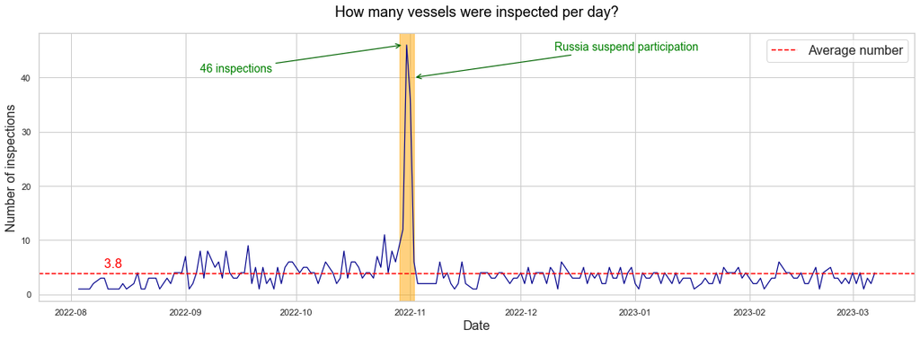

```python
# timeseries inspections per day

df_drate = final_df.inspection_cleared.value_counts().sort_index().reset_index()
df_drate.columns = ['date','number_of_inspection']

# sns.set_style("darkgrid")
rate_avg = df_drate['number_of_inspection'].mean()
rate_max = df_drate['number_of_inspection'].max()

sns.set_style("whitegrid")
fig, ax = plt.subplots(figsize=(16, 6))
sns.lineplot(ax=ax, data=df_drate,
             x='date',
             y='number_of_inspection',
             color='darkblue',
             linewidth=1.2)

plt.title('How many vessels were inspected per day?',
          color='black',
          fontsize=18,
         pad =20)
plt.ylabel('Number of inspections', fontsize=16)
plt.xlabel('Date', fontsize=16)
plt.axhline(y=rate_avg,
            xmin=0,
            linestyle='--',
            color='red',
            label='Average number')

ax.axvspan(
     datetime(2022,10,29),
    datetime(2022,11,2),
    color='orange',
    alpha=0.5,
)

plt.annotate(
    "Russia suspend participation",
    xy=(datetime(2022,11,2), 40),
    xytext=(datetime(2022,12,10), 45),
    xycoords='data',
    color="green",
    fontsize=14,
    arrowprops=dict(arrowstyle='->',
                    color='darkgreen',
                    linewidth=1.2)
)
plt.annotate('3.8 ',
            xy=(datetime(2022,8, 10), 5),
            xytext=(datetime(2022,8, 10), 5),
             fontsize=16,
            color='red')

plt.annotate(str(rate_max) +' inspections',
             xy=(datetime(2022,10,30), 46),
            xytext=(datetime(2022,9, 5), 41),
             fontsize=14,
            color='green',
            arrowprops=dict(arrowstyle='->',
                    color='darkgreen',
                    linewidth=1.2))

plt.legend(fontsize=16)
plt.tight_layout()
plt.show()
```

```python
# plot total tonnage per day

df2 = final_df.groupby('inspection_cleared')['tonnage'].agg(['sum', 'count'])
tonnage_max = round(df2['sum'].max()/10**6, 1)
```

```python
df2.head()
```

| inspection_cleared | sum | count |
| --- | --- | --- |
| 2022-08-03 | 26527.0 | 1 |
| 2022-08-06 | 33000.0 | 1 |
| 2022-08-07 | 25041.0 | 2 |
| 2022-08-09 | 155084.0 | 3 |
| 2022-08-10 | 65459.0 | 3 |

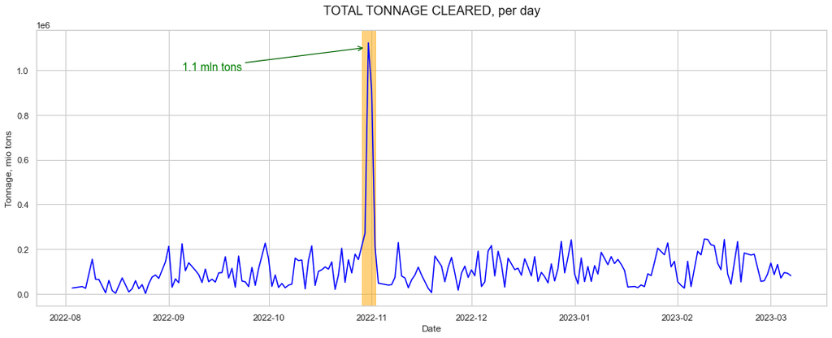

```python
sns.set_style("whitegrid")
fig, ax = plt.subplots(figsize=(16, 6))
sns.lineplot(ax=ax, data=df2,
             x=df2.index,
             y='sum',
             color='blue',
             linewidth=1.5)
ax.set_title('TOTAL TONNAGE CLEARED, per day',
             fontsize=16,
             color='k',
            pad=20)
ax.set_xlabel('Date')
ax.set_ylabel('Tonnage, mio tons')

plt.annotate(str(tonnage_max) +' mln tons',
            xy=(datetime(2022,10,30), tonnage_max*10**6),
            xytext=(datetime(2022,9, 5), 1000500),
            fontsize=14,
            color='green',
            arrowprops=dict(arrowstyle='->',
                    color='darkgreen',
                    linewidth=1.2))

ax.axvspan(
     datetime(2022,10,29),
    datetime(2022,11,2),
    color='orange',
    alpha=0.5,
)
# sns.despine()
plt.show()
```

```python
df2['sum'].mean()
```

```
112287.34343434343
```

```python
# plotting downtime mean cleared per day vs rate of inspection

df4 = final_df.groupby('inspection_cleared').agg({ 'downtime': 'mean', 'inspection_cleared': 'count'})
```

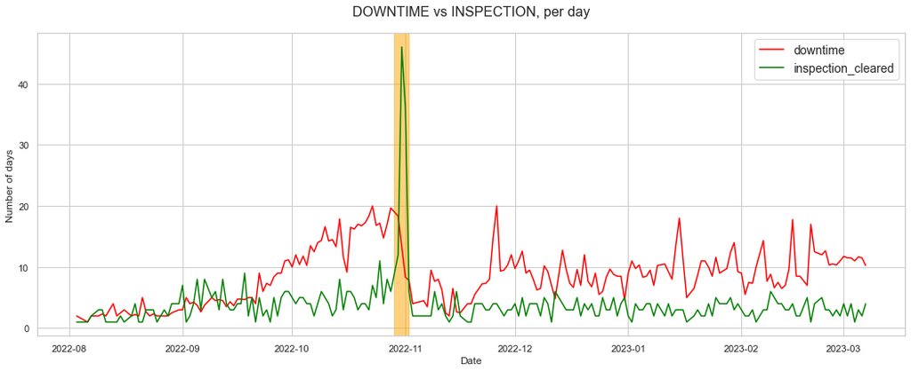

```python
sns.set_style("whitegrid")
fig, ax = plt.subplots(figsize=(16, 6))

sns.lineplot(ax=ax, data=df4[['downtime', 'inspection_cleared']],
             linewidth=1.5,
             palette=['red', 'green'],
            dashes=False)


plt.title('DOWNTIME vs INSPECTION, per day',
         fontsize=16,
         pad=20)
plt.xlabel('Date')
plt.ylabel('Number of days')

plt.axvspan(
     datetime(2022,10,29),
    datetime(2022,11,2),
    color='orange',
    alpha=0.5,
)
plt.legend(fontsize=14)
# sns.despine()
plt.show()
```

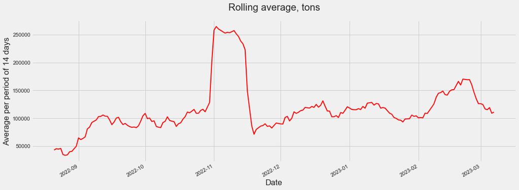

```python
plt.style.use('fivethirtyeight')
period = 14
df_ton_rolling = df2['sum'].rolling(window=period).mean()

df_ton_rolling.plot(figsize=(16, 6),
                     linewidth=2,
                     color='red')
plt.xlabel('Date')
plt.ylabel('Average per period of ' +str(period) + ' days')
plt.title('Rolling average, tons',
         pad=20)
plt.show()
```

In above graphs we can observe the slight tendency of shippers to increase the tonnage of ships

### Step 5: Question

**To what extent could the total volume of commodities deliveries increase, given the current level of inspections, if vessel tonnage increases?** We will make calculations based on the conditions of the previous period, taking into account the proposal of the Ministry of Agrarian Policy of Ukraine to increase the minimum tonnage for the transportation of oils up to 10,000 tons, for meal - 15,000 tons, for other bulk cargo - up to 25,000 tons.

```python
final_df.commodity.unique()
```

```
array(['Corn', 'Sunflower meal', 'Wheat', 'Sunflower oil', 'Barley',
       'Soya beans', 'Rapeseed', 'Sunflower seed', 'Peas',
       'Vegetable oil', 'Canola', 'Rapeseed meal', 'Sunflower pellets',
       'Mixed', 'Wheat bran pellets', 'Sugar beet pellets'], dtype=object)
```

```python
oil = ['Sunflover oil', 'Vegetable oil']
meal = ['Sunflower meal', 'Rapeseed meal']
```

```python
(final_df.commodity.isin(meal)).value_counts()
```

```
False    720
True      47
Name: commodity, dtype: int64
```

```python
final_df['abstract_tonnage'] = final_df.tonnage
```

```python
# changing tonnage of the vessels to hypotetic increased value

final_df.loc[final_df.commodity.isin(oil) & (final_df.tonnage <10000), 'abstract_tonnage'] = 10000
final_df.loc[final_df.commodity.isin(meal) & (final_df.tonnage <15000), 'abstract_tonnage'] = 15000
final_df.loc[~final_df.commodity.isin(meal) & ~final_df.commodity.isin(oil) & (final_df.tonnage <25000), 'abstract_tonnage'] = 25000
```

```python
final_df.abstract_tonnage.sum()
```

```
27115783.0
```

```python
final_df.tonnage.sum()
```

```
22232894.0
```

```python
increase_tonnage = (final_df.abstract_tonnage.sum() - final_df.tonnage.sum()) / final_df.tonnage.sum() * 100
```

```python
print(f'Given the current level of inspections the vessels tonnage increase as minimum for oil up to 10 000 ton, for meal - up to 15 000 tonn and for the rest of bulk cargo up to 25 000 ton, the total volume of commodities deliveries under Black Sea Grain Initiative might increase by {round(increase_tonnage, 1)}%.')
```

[output not shown]